# Principal Component Analysis of the Climate Environment for the Madrean Sky Islands

SLH

7/14/2020

### Introduction

Purpose: Conduct principal components analysis with bioclim data for the sky islands and assign values to output rasters

Author: original script by E. Whitman and E. Batllori for analysis published in the following paper: Whitman, E., E. Batllori, M.-A. Parisien, C. Miller, J.D. Coop, M.A. Krawchuk, G.W. Chong, and S.L. Haire. 2015. The Climate Space of Fire Regimes in North-Western North America. Journal of Biogeography 42 (9): 1736:49. https://doi.org/10.1111/jbi.12533.

Revised by S. Haire, @HaireLab

Notes: Climate data (1981-2010 climate normals) can be downloaded from < https://adaptwest.databasin.org/pages/adaptwest-climatena >

Sky Island polygons are described here: Deyo, Nicholas S.; Van Devender, Thomas R.; Smith, Alex; Gilbert, Edward. 2013. Documenting the biodiversity of the Madrean Archipelago: An analysis of a virtual flora and fauna. In: Gottfried, Gerald J.; Ffolliott, Peter F.; Gebow, Brooke S.; Eskew, Lane G.; Collins, Loa C. Merging science and management in a rapidly changing world: Biodiversity and management of the Madrean Archipelago III and 7th Conference on Research and Resource Management in the Southwestern Deserts; 2012 May 1-5; Tucson, AZ. Proceedings. RMRS-P-67. Fort Collins, CO: U.S. Department of Agriculture, Forest Service, Rocky Mountain Research Station. p. 292-299.)

We edited the original version to close a polygon gap on Huachuca (see Sky_Island_Complexes_edit.shp available in data folder).

### Steps

1. Prepare the bioclim data by cropping to the extent of the Sky Islands and using the island polygons as a mask (55 islands)
2. Read in the data and generate an index with a ‘pixel.code’.
3. Run the principal components analysis and use the pixel code to set back the PCA values to rasters.
4. Plot the PC rasters. Note: We used a subset of the 55 islands in subsequent analysis. The subsetted PC’s are available in graphic form as a manuscript supplement.

### Loadings table

```
##                  PC1         PC2
## AHM     -0.101761829  0.37655385
## bFFP     0.272570546  0.04428494
## CMD     -0.220390371  0.21943183
## DD_0     0.247637003 -0.05026348
## DD_5    -0.281157792  0.02041583
## eFFP    -0.268726390 -0.06538533
## EMT     -0.270710821 -0.06581850
## Eref    -0.262358131  0.03974809
## MAP     -0.009513314 -0.40588184
## MAT     -0.281816322  0.02281065
## MCMT    -0.280350299 -0.05256989
## MSP     -0.109376707 -0.37298066
## MWMT    -0.261239864  0.13417956
## NFFD    -0.269575318 -0.02292941
## PPT_sm  -0.120982888 -0.36051154
## PPT_wt   0.126726235 -0.26023407
## SHM      0.014099436  0.38613494
## Tave_sm -0.267290966  0.11456867
## Tave_wt -0.281397740 -0.04421118
## TD       0.139864781  0.32775852
```

### PC rasters

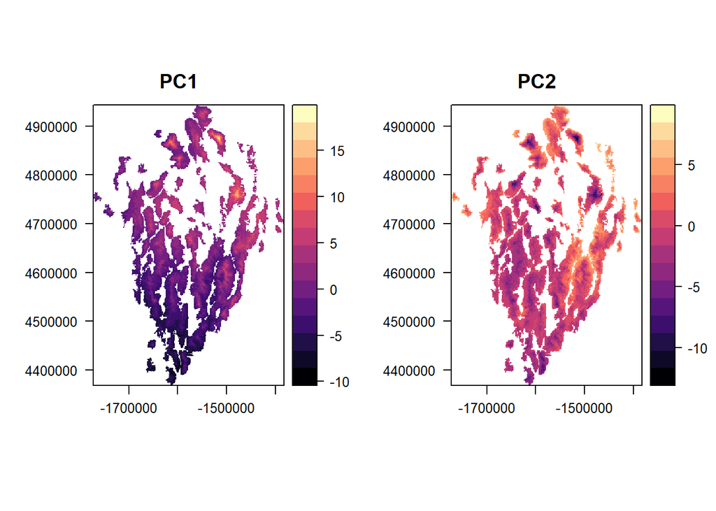